# Repaso parcial 2

### Problema 3

*Genere pronósticos para todas los animales del estado de Victoria en `aus_livestock` utilizando `SNAIVE()`. Grafique los pronósticos resultantes junto con los datos históricos. ¿Este método es una referencia adecuada para los datos?*

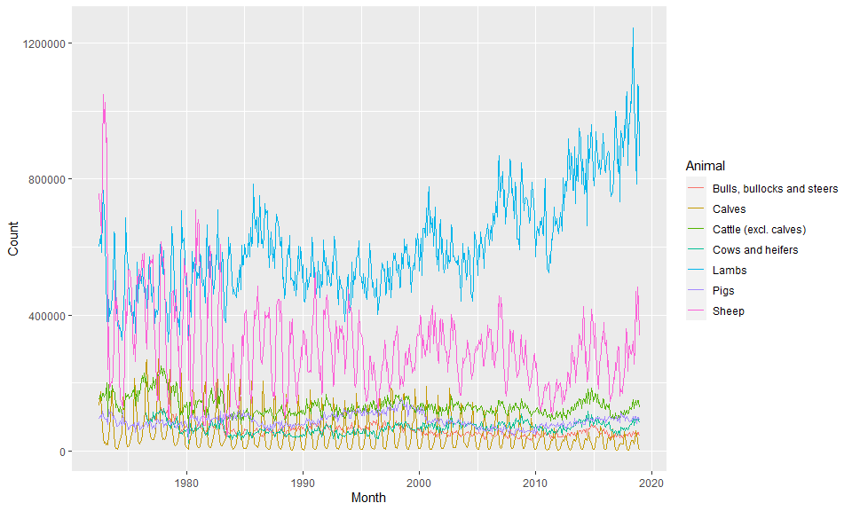

```r
victoria <- aus_livestock %>%
  filter(State == "Victoria") %>%
  select(-c(State))

victoria %>%
  ggplot(aes(x = Month, y = Count, color = Animal)) +
  geom_line()
```

Los pronósticos:

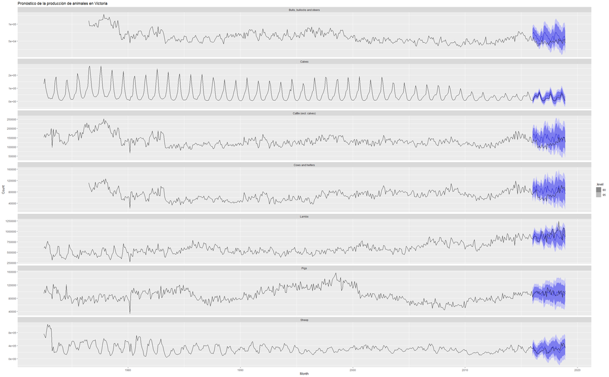

```r
victoria_train <- victoria %>%
  filter(Month <"2016-01-01")

# Ajuste del modelo SNAIVE
victoria_model <- victoria_train %>%
  model(snaive = SNAIVE(Count))

# Obtener residuales y valores ajustados
victoria_aug <- victoria_model %>% augment()

# El pronóstico

victoria_fc <- victoria_model %>%
  forecast(h = 36) # pronóstico de 3 años

# Gráfica de los pronósticos
victoria_fc %>%
  autoplot(victoria) + ggtitle("Pronóstico de la producción de animales en Victoria")
```

Para revisar la precisión del modelo en cada animal:

```r
accuracy(victoria_fc, victoria)
```

| .model | Animal | .type | ME | RMSE | MAE | MPE | MAPE | MASE | ACF1 |
| --- | --- | --- | --- | --- | --- | --- | --- | --- | --- |
| snaive | Bulls, bullocks and steers | Test | -14772.222 | 16630.310 | 14838.889 | -32.1364330 | 32.268708 | 1.7693155 | 0.5571198 |
| snaive | Calves | Test | -8427.778 | 10608.330 | 8450.000 | -47.5207423 | 47.588082 | 0.9026076 | 0.7346573 |
| snaive | Cattle (excl. calves) | Test | -29000.000 | 35231.796 | 30522.222 | -26.6090728 | 27.668285 | 1.6315543 | 0.7032636 |
| snaive | Cows and heifers | Test | -14225.000 | 20457.768 | 17947.222 | -23.9336650 | 27.936423 | 1.4227208 | 0.7198791 |
| snaive | Lambs | Test | 56305.556 | 118548.159 | 93877.778 | 5.0380325 | 9.824003 | 1.4583689 | 0.4472059 |
| snaive | Pigs | Test | 1233.333 | 7692.493 | 6355.556 | 0.8324868 | 6.605810 | 0.6658176 | -0.2601586 |
| snaive | Sheep | Test | -14133.333 | 75137.810 | 60622.222 | -10.8319046 | 23.402497 | 0.7958314 | 0.5887734 |

### Problema 4

*Calcule los residuos del pronóstico naïve estacional aplicados a la producción trimestral de cerveza australiana a partir de 1992. El siguiente código puede serles útil. ¿Qué puede concluir al respecto?*

```r
# Extraer los datos de interés
recent_production <- aus_production %>%
  filter(year(Quarter) >= 1992)

# Definir y estimar el modelo
fit <- recent_production %>% model(SNAIVE(Beer))

# Ver los residuales
fit %>% gg_tsresiduals()

# Ver el pronóstico resultante
fit %>% forecast() %>% autoplot(recent_production)
```

[output not shown]

### Problema 5

*Repita el ejercicio anterior utilizando las exportaciones mexicanas de `global_economy` y la serie de tiempo de ladrillos (Bricks) de `aus_production`. Utilice cualquiera entre `NAIVE()` o `SNAIVE()` dependiendo cuál sea más conveniente en cada caso.*

### Problema 6

*Explique si los siguientes enunciados son verdaderos o falsos y por qué:*

1. Buenos métodos de pronóstico deben tener residuos normalmente distribuidos.
2. Un modelo con residuos pequeños va a producir buenos pronósticos.
3. La mejor medida de precisión del pronóstico es el MAPE.
4. Si el modelo no pronostica bien, debería hacerlo más complicado.
5. Siempre hay que escoger el modelo con la mejor precisión en el pronóstico, medido a través del conjunto de prueba (pronóstico).